# 1. Business Problem

## 1.1 Description

Quora is a place to gain and share knowledge—about anything. It’s a platform to ask questions and connect with people who contribute unique insights and quality answers. This empowers people to learn from each other and to better understand the world.

Over 100 million people visit Quora every month, so it's no surprise that many people ask similarly worded questions. Multiple questions with the same intent can cause seekers to spend more time finding the best answer to their question, and make writers feel they need to answer multiple versions of the same question. Quora values canonical questions because they provide a better experience to active seekers and writers, and offer more value to both of these groups in the long term.

> Credits: Kaggle

**Problem Statement**

- Identify which questions asked on Quora are duplicates of questions that have already been asked.
- This could be useful to instantly provide answers to questions that have already been answered.
- We are tasked with predicting whether a pair of questions are duplicates or not.

## 1.2 Real world/Business Objectives and Constraints

1. The cost of a mis-classification can be very high.
2. You would want a probability of a pair of questions to be duplicates so that you can choose any threshold of choice.
3. No strict latency concerns.
4. Interpretability is partially important.

# 2. Machine Learning Probelm

## 2.2 Mapping the real world problem to an ML problem

### 2.2.1 Type of Machine Leaning Problem

It is a binary classification problem, for a given pair of questions we need to predict if they are duplicate or not.

### 2.2.2 Performance Metric

Metric(s):

- Log-Loss
- Binary Confusion Matrix

## 2.3 Train and Test Construction

We build train and test by randomly splitting in the ratio of 70:30 or 80:20 whatever we choose as we have sufficient points to work with.

# 3. Exploratory Data Analysis

```python
# Importing the libraries
%matplotlib inline
import warnings
warnings.filterwarnings("ignore")
import numpy as np
import pandas as pd
import seaborn as sns
import matplotlib.pyplot as plt
from subprocess import check_output

import plotly.offline as py
py.init_notebook_mode(connected=True)
import plotly.graph_objs as go
import plotly.tools as tls
from os import path
import gc

import nltk
import re
import os
from nltk.corpus import stopwords
import distance
from nltk.stem import PorterStemmer
from bs4 import BeautifulSoup

# This package is used for finding longest common subsequence between two strings
# you can write your own dp code for this

from fuzzywuzzy import fuzz
from sklearn.manifold import TSNE
# Import the Required lib packages for WORD-Cloud generation
# https://stackoverflow.com/questions/45625434/how-to-install-wordcloud-in-python3-6
from wordcloud import WordCloud, STOPWORDS

from sklearn.preprocessing import MinMaxScaler

from sklearn.feature_extraction.text import TfidfVectorizer
from sklearn.feature_extraction.text import CountVectorizer

from tqdm import tqdm

# exctract word2vec vectors
# https://github.com/explosion/spaCy/issues/1721
# http://landinghub.visualstudio.com/visual-cpp-build-tools
import spacy

from xgboost import XGBClassifier
from sklearn.model_selection import RandomizedSearchCV
from sklearn.calibration import CalibratedClassifierCV
import pickle
import sqlite3
from sqlalchemy import create_engine # database connection
import csv
import datetime as dt
from sklearn.metrics import confusion_matrix,log_loss
from collections import Counter
from sklearn.model_selection import train_test_split
import math

from sklearn.linear_model import SGDClassifier
from imblearn.under_sampling import RandomUnderSampler # For UnderSampling

import pickle
```

```python
df = pd.read_csv("train.csv")
print("Number of data points:",df.shape[0])
```

```
Number of data points: 404290
```

```python
df.head()
```

|  | id | qid1 | qid2 | question1 | question2 | is_duplicate |
| --- | --- | --- | --- | --- | --- | --- |
| 0 | 0 | 1 | 2 | What is the step by step guide to invest in sh... | What is the step by step guide to invest in sh... | 0 |
| 1 | 1 | 3 | 4 | What is the story of Kohinoor (Koh-i-Noor) Dia... | What would happen if the Indian government sto... | 0 |
| 2 | 2 | 5 | 6 | How can I increase the speed of my internet co... | How can Internet speed be increased by hacking... | 0 |
| 3 | 3 | 7 | 8 | Why am I mentally very lonely? How can I solve... | Find the remainder when [math]23^{24}[/math] i... | 0 |
| 4 | 4 | 9 | 10 | Which one dissolve in water quikly sugar, salt... | Which fish would survive in salt water? | 0 |

```python
df.info()
```

```
<class 'pandas.core.frame.DataFrame'>
RangeIndex: 404290 entries, 0 to 404289
Data columns (total 6 columns):
 #   Column        Non-Null Count   Dtype
---  ------        --------------   -----
 0   id            404290 non-null  int64
 1   qid1          404290 non-null  int64
 2   qid2          404290 non-null  int64
 3   question1     404289 non-null  object
 4   question2     404288 non-null  object
 5   is_duplicate  404290 non-null  int64
dtypes: int64(4), object(2)
memory usage: 18.5+ MB
```

We are given a minimal number of data fields here, consisting of:

- id: Looks like a simple rowID
- qid{1, 2}: The unique ID of each question in the pair
- question{1, 2}: The actual textual contents of the questions.
- is_duplicate: The label that we are trying to predict - whether the two questions are duplicates of each other.

### 3.2.1 Distribution of data points among output classes

- Number of duplicate(smilar) and non-duplicate(non similar) questions

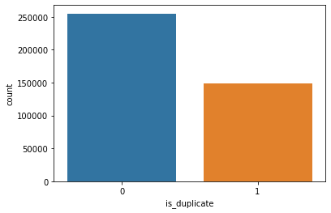

```python
sns.countplot(data=df,x='is_duplicate')
plt.show()
```

```python
print('Question pairs are not Similar (is_duplicate = 0): {}%'.format(100 - round(df['is_duplicate'].mean()*100, 2)))
print('Question pairs are Similar (is_duplicate = 1): {}%'.format(round(df['is_duplicate'].mean()*100, 2)))
```

```
Question pairs are not Similar (is_duplicate = 0): 63.08%
Question pairs are Similar (is_duplicate = 1): 36.92%
```

### 3.2.2 Number of unique questions

```python
qids = pd.Series(df['qid1'].tolist() + df['qid2'].tolist())
unique_qs = len(np.unique(qids))
qs_morethan_onetime = np.sum(qids.value_counts() > 1)

print ('Total number of  Unique Questions are: {}'.format(unique_qs))
print ('Number of unique questions that appear more than one time: {} ({}%)'.format(qs_morethan_onetime,qs_morethan_onetime/unique_qs*100))
print ('Max number of times a single question is repeated: {}'.format(max(qids.value_counts())))

q_vals=qids.value_counts()
q_vals=q_vals.values
```

```
Total number of  Unique Questions are: 537933
Number of unique questions that appear more than one time: 111780 (20.77953945937505%)
Max number of times a single question is repeated: 157
```

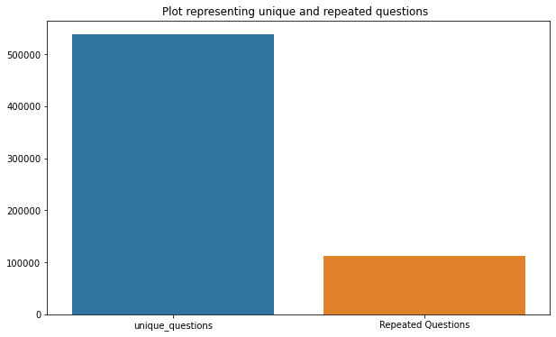

```python
x = ["unique_questions" , "Repeated Questions"]
y =  [unique_qs , qs_morethan_onetime]

plt.figure(figsize=(10, 6))
plt.title ("Plot representing unique and repeated questions  ")
sns.barplot(x=x,y=y)
plt.show()
```

### 3.2.3 Checking for Duplicates

```python
#checking whether there are any repeated pair of questions
pair_duplicates = df[['qid1','qid2','is_duplicate']].groupby(['qid1','qid2']).count().reset_index()
print ("Number of duplicate questions",(pair_duplicates).shape[0] - df.shape[0])
```

```
Number of duplicate questions 0
```

### 3.2.4 Number of occurrences of each question

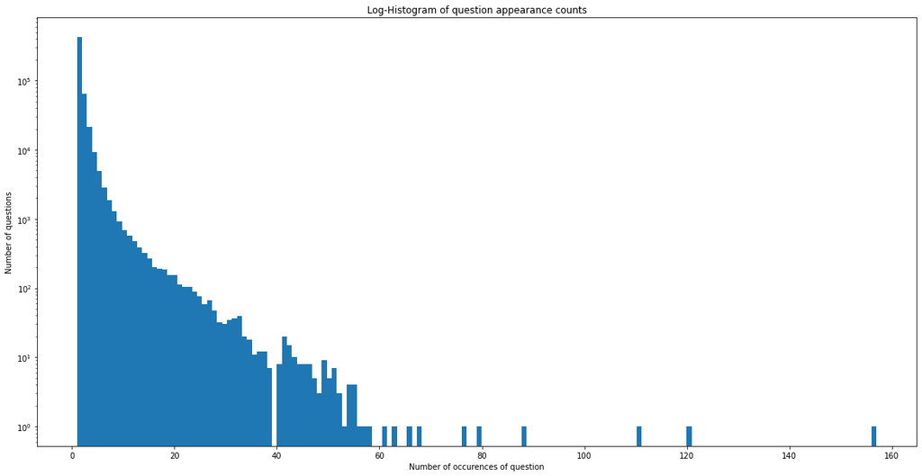

```
Maximum number of times a single question is repeated: 157
```

```python
plt.figure(figsize=(20, 10))
plt.hist(qids.value_counts(), bins=160)
plt.yscale('log', nonpositive='clip')
plt.title('Log-Histogram of question appearance counts')
plt.xlabel('Number of occurences of question')
plt.ylabel('Number of questions')
plt.show()
print ('Maximum number of times a single question is repeated: {}\n'.format(max(qids.value_counts())))
```

### 3.2.5 Checking for NULL values

```python
#Checking whether there are any rows with null values
nan_rows = df[df.isnull().any(1)]
print (nan_rows)
```

```
            id    qid1    qid2                         question1  \
105780  105780  174363  174364    How can I develop android app?
201841  201841  303951  174364  How can I create an Android app?
363362  363362  493340  493341                               NaN

                                                question2  is_duplicate
105780                                                NaN             0
201841                                                NaN             0
363362  My Chinese name is Haichao Yu. What English na...             0
```

```python
# Filling the null values with ' '
df = df.fillna('')
nan_rows = df[df.isnull().any(1)]
print (nan_rows)
```

```
Empty DataFrame
Columns: [id, qid1, qid2, question1, question2, is_duplicate]
Index: []
```

# 4. EDA: Feature Extraction

## 4.1 Preprocessing of Text

- Preprocessing:
  - Removing html tags
  - Removing Punctuations
  - Performing stemming
  - Removing Stopwords
  - Expanding contractions etc.

```python
# To get the results in 4 decemal points
SAFE_DIV = 0.0001
STOP_WORDS = stopwords.words("english")
def preprocess(x):
    x = str(x).lower()
    x = x.replace(",000,000", "m").replace(",000", "k").replace("′", "'").replace("’", "'")\
                           .replace("won't", "will not").replace("cannot", "can not").replace("can't", "can not")\
                           .replace("n't", " not").replace("what's", "what is").replace("it's", "it is")\
                           .replace("'ve", " have").replace("i'm", "i am").replace("'re", " are")\
                           .replace("he's", "he is").replace("she's", "she is").replace("'s", " own")\
                           .replace("%", " percent ").replace("₹", " rupee ").replace("$", " dollar ")\
                           .replace("€", " euro ").replace("'ll", " will")
    x = re.sub(r"([0-9]+)000000", r"\1m", x)
    x = re.sub(r"([0-9]+)000", r"\1k", x)

    porter = PorterStemmer()
    pattern = re.compile('\W')

    if type(x) == type(''):
        x = re.sub(pattern, ' ', x)

    if type(x) == type(''):
        x = porter.stem(x)
        example1 = BeautifulSoup(x)
        x = example1.get_text()

    return x
```

## 4.2 Advanced Feature Extraction (NLP and Fuzzy Features)

Definition:

- **Token**: You get a token by splitting sentence a space
- **Stop_Word** : stop words as per NLTK.
- **Word** : A token that is not a stop_word

Features:

- **cwc_min** : Ratio of common_word_count to min lenghth of word count of Q1 and Q2  
  cwc_min = common_word_count / (min(len(q1_words), len(q2_words))
- **cwc_max** : Ratio of common_word_count to max lenghth of word count of Q1 and Q2  
  cwc_max = common_word_count / (max(len(q1_words), len(q2_words))
- **csc_min** : Ratio of common_stop_count to min lenghth of stop count of Q1 and Q2  
  csc_min = common_stop_count / (min(len(q1_stops), len(q2_stops))
- **csc_max** : Ratio of common_stop_count to max lenghth of stop count of Q1 and Q2  
  csc_max = common_stop_count / (max(len(q1_stops), len(q2_stops))
- **ctc_min** : Ratio of common_token_count to min lenghth of token count of Q1 and Q2  
  ctc_min = common_token_count / (min(len(q1_tokens), len(q2_tokens))
- **ctc_max** : Ratio of common_token_count to max lenghth of token count of Q1 and Q2  
  ctc_max = common_token_count / (max(len(q1_tokens), len(q2_tokens))
- **last_word_eq** : Check if First word of both questions is equal or not  
  last_word_eq = int(q1_tokens[-1] == q2_tokens[-1])
- **first_word_eq** : Check if First word of both questions is equal or not  
  first_word_eq = int(q1_tokens[0] == q2_tokens[0])
- **abs_len_diff** : Abs. length difference  
  abs_len_diff = abs(len(q1_tokens) - len(q2_tokens))
- **mean_len** : Average Token Length of both Questions  
  mean_len = (len(q1_tokens) + len(q2_tokens))/2
- **fuzz_ratio** : https://github.com/seatgeek/fuzzywuzzy#usage http://chairnerd.seatgeek.com/fuzzywuzzy-fuzzy-string-matching-in-python/
- **fuzz_partial_ratio** : https://github.com/seatgeek/fuzzywuzzy#usage http://chairnerd.seatgeek.com/fuzzywuzzy-fuzzy-string-matching-in-python/
- **token_sort_ratio** : https://github.com/seatgeek/fuzzywuzzy#usage http://chairnerd.seatgeek.com/fuzzywuzzy-fuzzy-string-matching-in-python/
- **token_set_ratio** : https://github.com/seatgeek/fuzzywuzzy#usage http://chairnerd.seatgeek.com/fuzzywuzzy-fuzzy-string-matching-in-python/
- **longest_substr_ratio** : Ratio of length longest common substring to min lenghth of token count of Q1 and Q2  
  longest_substr_ratio = len(longest common substring) / (min(len(q1_tokens), len(q2_tokens))

```python
def get_token_features(q1, q2):
    token_features = [0.0]*10

    # Converting the Sentence into Tokens:
    q1_tokens = q1.split()
    q2_tokens = q2.split()

    if len(q1_tokens) == 0 or len(q2_tokens) == 0:
        return token_features
    # Get the non-stopwords in Questions
    q1_words = set([word for word in q1_tokens if word not in STOP_WORDS])
    q2_words = set([word for word in q2_tokens if word not in STOP_WORDS])

    #Get the stopwords in Questions
    q1_stops = set([word for word in q1_tokens if word in STOP_WORDS])
    q2_stops = set([word for word in q2_tokens if word in STOP_WORDS])

    # Get the common non-stopwords from Question pair
    common_word_count = len(q1_words.intersection(q2_words))
    # Get the common stopwords from Question pair
    common_stop_count = len(q1_stops.intersection(q2_stops))

    # Get the common Tokens from Question pair
    common_token_count = len(set(q1_tokens).intersection(set(q2_tokens)))

    token_features[0] = common_word_count / (min(len(q1_words), len(q2_words)) + SAFE_DIV)
    token_features[1] = common_word_count / (max(len(q1_words), len(q2_words)) + SAFE_DIV)
    token_features[2] = common_stop_count / (min(len(q1_stops), len(q2_stops)) + SAFE_DIV)
    token_features[3] = common_stop_count / (max(len(q1_stops), len(q2_stops)) + SAFE_DIV)
    token_features[4] = common_token_count / (min(len(q1_tokens), len(q2_tokens)) + SAFE_DIV)
    token_features[5] = common_token_count / (max(len(q1_tokens), len(q2_tokens)) + SAFE_DIV)

    # Last word of both question is same or not
    token_features[6] = int(q1_tokens[-1] == q2_tokens[-1])

    # First word of both question is same or not
    token_features[7] = int(q1_tokens[0] == q2_tokens[0])

    token_features[8] = abs(len(q1_tokens) - len(q2_tokens))

    #Average Token Length of both Questions
    token_features[9] = (len(q1_tokens) + len(q2_tokens))/2
    return token_features

# get the Longest Common sub string

def get_longest_substr_ratio(a, b):
    strs = list(distance.lcsubstrings(a, b))
    if len(strs) == 0:
        return 0
    else:
        return len(strs[0]) / (min(len(a), len(b)) + 1)

def extract_features(df):
    # preprocessing each question
    df["question1"] = df["question1"].fillna("").apply(preprocess)
    df["question2"] = df["question2"].fillna("").apply(preprocess)

    print("token features...")

    # Merging Features with dataset

    token_features = df.apply(lambda x: get_token_features(x["question1"], x["question2"]), axis=1)

    df["cwc_min"]       = list(map(lambda x: x[0], token_features))
    df["cwc_max"]       = list(map(lambda x: x[1], token_features))
    df["csc_min"]       = list(map(lambda x: x[2], token_features))
    df["csc_max"]       = list(map(lambda x: x[3], token_features))
    df["ctc_min"]       = list(map(lambda x: x[4], token_features))
    df["ctc_max"]       = list(map(lambda x: x[5], token_features))
    df["last_word_eq"]  = list(map(lambda x: x[6], token_features))
    df["first_word_eq"] = list(map(lambda x: x[7], token_features))
    df["abs_len_diff"]  = list(map(lambda x: x[8], token_features))
    df["mean_len"]      = list(map(lambda x: x[9], token_features))

    #Computing Fuzzy Features and Merging with Dataset

    # do read this blog: http://chairnerd.seatgeek.com/fuzzywuzzy-fuzzy-string-matching-in-python/
    # https://stackoverflow.com/questions/31806695/when-to-use-which-fuzz-function-to-compare-2-strings
    # https://github.com/seatgeek/fuzzywuzzy

    df["token_set_ratio"]       = df.apply(lambda x: fuzz.token_set_ratio(x["question1"], x["question2"]), axis=1)
    # The token sort approach involves tokenizing the string in question, sorting the tokens alphabetically, and
    # then joining them back into a string We then compare the transformed strings with a simple ratio().
    df["token_sort_ratio"]      = df.apply(lambda x: fuzz.token_sort_ratio(x["question1"], x["question2"]), axis=1)
    df["fuzz_ratio"]            = df.apply(lambda x: fuzz.QRatio(x["question1"], x["question2"]), axis=1)
    df["fuzz_partial_ratio"]    = df.apply(lambda x: fuzz.partial_ratio(x["question1"], x["question2"]), axis=1)
    df["longest_substr_ratio"]  = df.apply(lambda x: get_longest_substr_ratio(x["question1"], x["question2"]), axis=1)
    return df
```

Let us now construct a few features like:

- **q1len** = Length of q1
- **q2len** = Length of q2
- **q1_n_words** = Number of words in Question 1
- **q2_n_words** = Number of words in Question 2
- **word_Common** = (Number of common unique words in Question 1 and Question 2)
- **word_Total** =(Total num of words in Question 1 + Total num of words in Question 2)
- **word_share** = (word_common)/(word_Total)

```python
def normalized_word_Common(row):
    w1 = set(map(lambda word: word.lower().strip(), row['question1'].split(" ")))
    w2 = set(map(lambda word: word.lower().strip(), row['question2'].split(" ")))
    return 1.0 * len(w1 & w2)


def normalized_word_Total(row):
    w1 = set(map(lambda word: word.lower().strip(), row['question1'].split(" ")))
    w2 = set(map(lambda word: word.lower().strip(), row['question2'].split(" ")))
    return 1.0 * (len(w1) + len(w2))


def normalized_word_share(row):
    w1 = set(map(lambda word: word.lower().strip(), row['question1'].split(" ")))
    w2 = set(map(lambda word: word.lower().strip(), row['question2'].split(" ")))
    return 1.0 * len(w1 & w2)/(len(w1) + len(w2))
```

```python
if os.path.isfile('nlp_features_train.csv'):
    df = pd.read_csv("nlp_features_train.csv",encoding='latin-1')
    df.fillna('')
else:
    print("Extracting features for train:")
    df = pd.read_csv("train.csv")
    df = extract_features(df)
    df['q1len'] = df['question1'].str.len()
    df['q2len'] = df['question2'].str.len()
    df['q1_n_words'] = df['question1'].apply(lambda row: len(row.split(" ")))
    df['q2_n_words'] = df['question2'].apply(lambda row: len(row.split(" ")))
    df['word_Common'] = df.apply(normalized_word_Common, axis=1)
    df['word_Total'] = df.apply(normalized_word_Total, axis=1)
    df['word_share'] = df.apply(normalized_word_share, axis=1)
    print("Done......")
    df.to_csv("nlp_features_train.csv", index=False)
```

```python
df.head(2)
```

|  | id | qid1 | qid2 | question1 | question2 | is_duplicate | cwc_min | cwc_max | csc_min | csc_max | ... | fuzz_ratio | fuzz_partial_ratio | longest_substr_ratio | q1len | q2len | q1_n_words | q2_n_words | word_Common | word_Total | word_share |
| --- | --- | --- | --- | --- | --- | --- | --- | --- | --- | --- | --- | --- | --- | --- | --- | --- | --- | --- | --- | --- | --- |
| 0 | 0 | 1 | 2 | what is the step by step guide to invest in sh... | what is the step by step guide to invest in sh... | 0 | 0.999980 | 0.833319 | 0.999983 | 0.999983 | ... | 93 | 100 | 0.982759 | 66 | 57 | 15 | 13 | 12.0 | 25.0 | 0.480000 |
| 1 | 1 | 3 | 4 | what is the story of kohinoor koh i noor dia... | what would happen if the indian government sto... | 0 | 0.799984 | 0.399996 | 0.749981 | 0.599988 | ... | 66 | 75 | 0.596154 | 51 | 88 | 13 | 18 | 8.0 | 26.0 | 0.307692 |

2 rows × 28 columns

## 4.3 Analysis of some of the extracted features

```python
print ("Minimum length of the questions in question1 : " , min(df['q1_n_words']))

print ("Minimum length of the questions in question2 : " , min(df['q2_n_words']))

print ("Number of Questions with minimum length [question1] :", df[df['q1_n_words']== 1].shape[0])
print ("Number of Questions with minimum length [question2] :", df[df['q2_n_words']== 1].shape[0])
```

```
Minimum length of the questions in question1 :  1
Minimum length of the questions in question2 :  1
Number of Questions with minimum length [question1] : 36
Number of Questions with minimum length [question2] : 13
```

#### 4.3.1 Feature: word_share

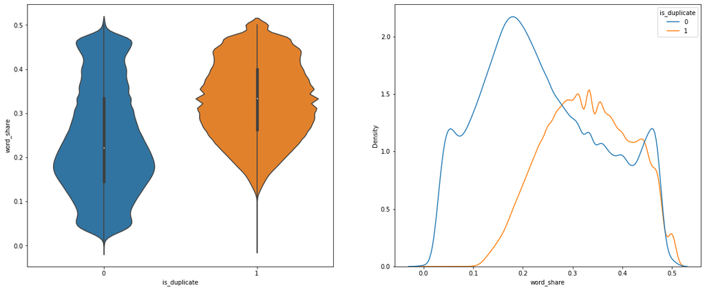

```python
plt.figure(figsize=(20, 8))

plt.subplot(1,2,1)
sns.violinplot(x = 'is_duplicate', y = 'word_share', data = df[0:])

plt.subplot(1,2,2)
sns.kdeplot(data=df[0:],x='word_share', hue='is_duplicate')
plt.show()
```

#### 4.3.2 Feature: word_Common

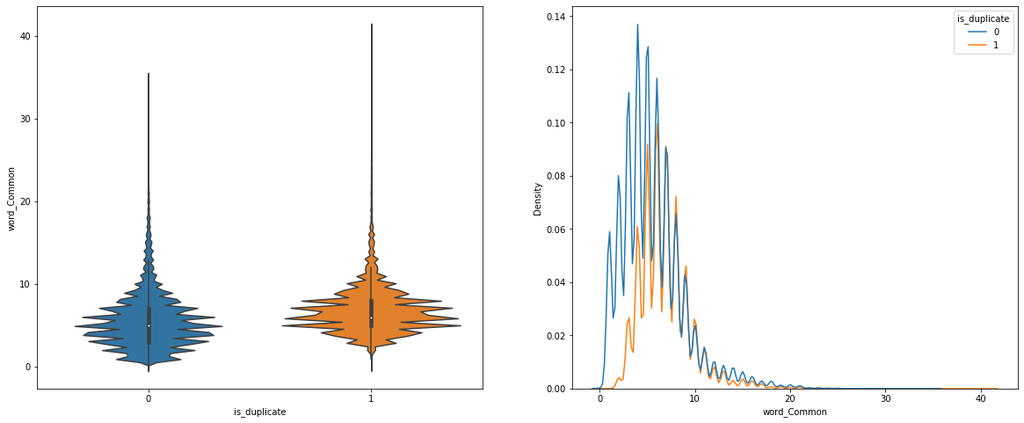

```python
plt.figure(figsize=(20, 8))

plt.subplot(1,2,1)
sns.violinplot(x = 'is_duplicate', y = 'word_Common', data = df[0:])

plt.subplot(1,2,2)
sns.kdeplot(data=df[0:],x='word_Common', hue='is_duplicate')
plt.show()
```

#### 4.3.3 Feature: token_sort_ratio

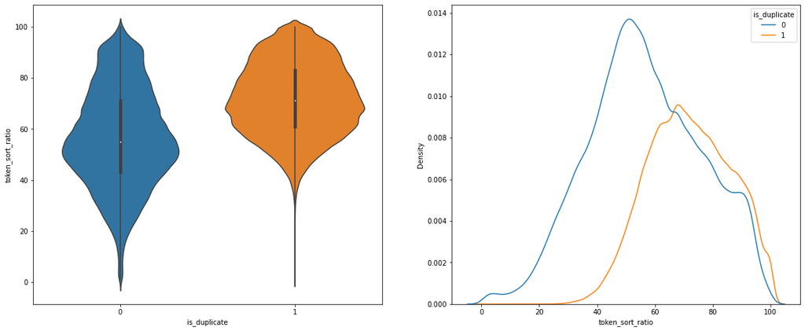

```python
# Distribution of the token_sort_ratio
plt.figure(figsize=(20, 8))

plt.subplot(1,2,1)
sns.violinplot(x = 'is_duplicate', y = 'token_sort_ratio', data = df[0:])

plt.subplot(1,2,2)
sns.kdeplot(data=df[0:],x='token_sort_ratio', hue='is_duplicate')
plt.show()
```

#### 4.3.4 Feature: fuzz_ratio

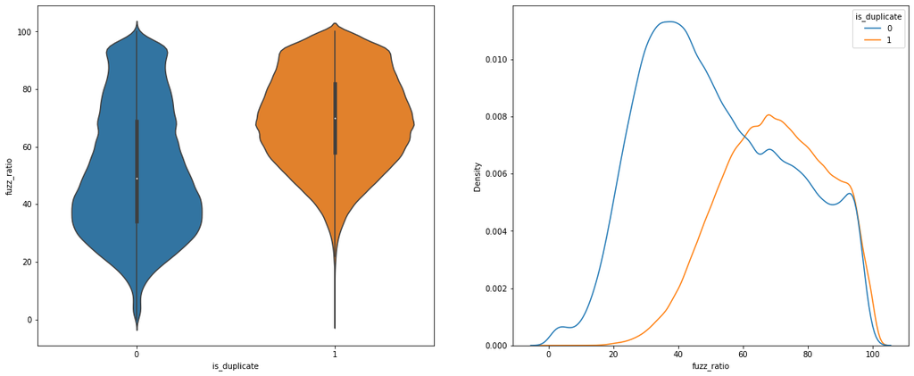

```python
plt.figure(figsize=(20, 8))

plt.subplot(1,2,1)
sns.violinplot(x = 'is_duplicate', y = 'fuzz_ratio', data = df[0:])

plt.subplot(1,2,2)
sns.kdeplot(data=df[0:],x='fuzz_ratio', hue='is_duplicate')
plt.show()
```

#### 4.3.5 Plotting Word clouds

```python
df_duplicate = df[df['is_duplicate'] == 1]
dfp_nonduplicate = df[df['is_duplicate'] == 0]

# Converting 2d array of q1 and q2 and flatten the array: like {{1,2},{3,4}} to {1,2,3,4}
p = np.dstack([df_duplicate["question1"], df_duplicate["question2"]]).flatten()
n = np.dstack([dfp_nonduplicate["question1"], dfp_nonduplicate["question2"]]).flatten()

print ("Number of data points in class 1 (duplicate pairs) :",len(p))
print ("Number of data points in class 0 (non duplicate pairs) :",len(n))

#Saving the np array into a text file
np.savetxt('train_p.txt', p, delimiter=' ', fmt='%s',encoding='utf-8')
np.savetxt('train_n.txt', n, delimiter=' ', fmt='%s',encoding='utf-8')
```

```
Number of data points in class 1 (duplicate pairs) : 298526
Number of data points in class 0 (non duplicate pairs) : 510054
```

```python
# reading the text files and removing the Stop Words:
d = path.dirname('.')
textp_w = open(path.join(d, 'train_p.txt'),encoding='utf-8').read()
textn_w = open(path.join(d, 'train_n.txt'),encoding='utf-8').read()
stopwords = set(STOPWORDS)
stopwords.add("said")
stopwords.add("br")
stopwords.add(" ")
stopwords.remove("not")
stopwords.remove("no")
stopwords.remove("like")
print ("Total number of words in duplicate pair questions :",len(textp_w))
print ("Total number of words in non duplicate pair questions :",len(textn_w))
```

```
Total number of words in duplicate pair questions : 16110954
Total number of words in non duplicate pair questions : 33201584
```

```
Word Cloud for Duplicate Question pairs
```

[figure not shown]

```python
wc = WordCloud(background_color="white", max_words=len(textp_w), stopwords=stopwords)
wc.generate(textp_w)
print ("Word Cloud for Duplicate Question pairs")
plt.imshow(wc, interpolation='bilinear')
plt.axis("off")
plt.show()
```

```
Word Cloud for non-Duplicate Question pairs:
```

[figure not shown]

```python
wc = WordCloud(background_color="white", max_words=len(textn_w),stopwords=stopwords)
# generate word cloud
wc.generate(textn_w)
print ("Word Cloud for non-Duplicate Question pairs:")
plt.imshow(wc, interpolation='bilinear')
plt.axis("off")
plt.show()
```

#### 4.3.6 Pair plot of features ['ctc_min', 'cwc_min', 'csc_min', 'token_sort_ratio']

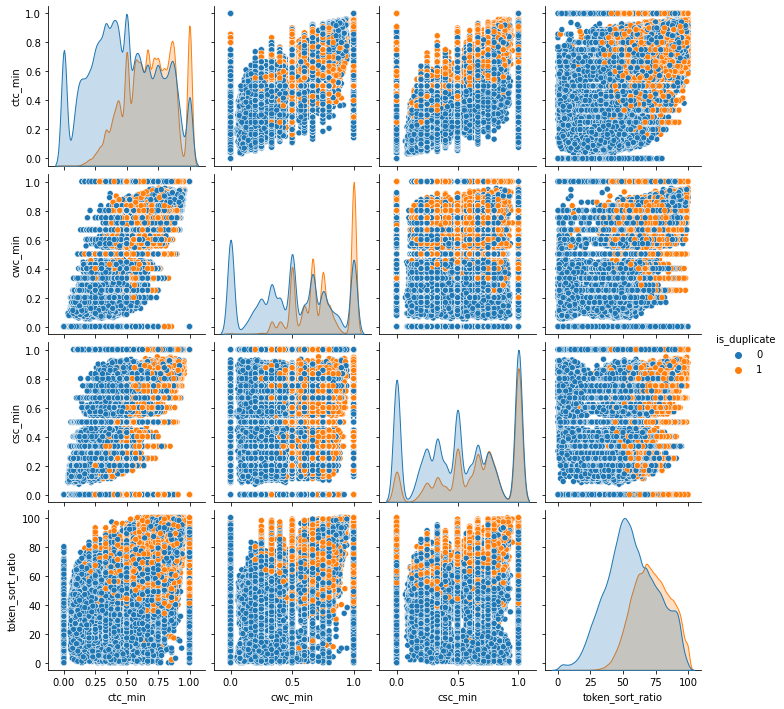

```python
n = df.shape[0]
sns.pairplot(df[['ctc_min', 'cwc_min', 'csc_min', 'token_sort_ratio', 'is_duplicate']][0:n], hue='is_duplicate', vars=['ctc_min', 'cwc_min', 'csc_min', 'token_sort_ratio'])
plt.show()
```

# 5. Visualization

#### 5.1 TSNE

```python
dfp_subsampled = df[0:5000]
X = MinMaxScaler().fit_transform(dfp_subsampled[['cwc_min', 'cwc_max', 'csc_min', 'csc_max' , 'ctc_min' , 'ctc_max' , 'last_word_eq', 'first_word_eq' , 'abs_len_diff' , 'mean_len' , 'token_set_ratio' , 'token_sort_ratio' ,  'fuzz_ratio' , 'fuzz_partial_ratio' , 'longest_substr_ratio']])
y = dfp_subsampled['is_duplicate'].values
```

```python
tsne2d = TSNE(
    n_components=2,
    init='random', # pca
    random_state=101,
    method='barnes_hut',
    n_iter=1000,
    verbose=2,
    angle=0.5
).fit_transform(X)
```

```
[t-SNE] Computing 91 nearest neighbors...
[t-SNE] Indexed 5000 samples in 0.026s...
[t-SNE] Computed neighbors for 5000 samples in 0.333s...
[t-SNE] Computed conditional probabilities for sample 1000 / 5000
[t-SNE] Computed conditional probabilities for sample 2000 / 5000
[t-SNE] Computed conditional probabilities for sample 3000 / 5000
[t-SNE] Computed conditional probabilities for sample 4000 / 5000
[t-SNE] Computed conditional probabilities for sample 5000 / 5000
[t-SNE] Mean sigma: 0.131928
[t-SNE] Computed conditional probabilities in 0.185s
[t-SNE] Iteration 50: error = 81.3534622, gradient norm = 0.0532696 (50 iterations in 1.421s)
[t-SNE] Iteration 100: error = 70.6857834, gradient norm = 0.0106284 (50 iterations in 1.175s)
[t-SNE] Iteration 150: error = 69.0271606, gradient norm = 0.0053264 (50 iterations in 1.149s)
[t-SNE] Iteration 200: error = 68.2512131, gradient norm = 0.0047586 (50 iterations in 1.162s)
[t-SNE] Iteration 250: error = 67.7725372, gradient norm = 0.0034672 (50 iterations in 1.170s)
[t-SNE] KL divergence after 250 iterations with early exaggeration: 67.772537
[t-SNE] Iteration 300: error = 1.7923481, gradient norm = 0.0011795 (50 iterations in 1.103s)
[t-SNE] Iteration 350: error = 1.3962560, gradient norm = 0.0004828 (50 iterations in 1.071s)
[t-SNE] Iteration 400: error = 1.2324462, gradient norm = 0.0002760 (50 iterations in 1.083s)
[t-SNE] Iteration 450: error = 1.1437513, gradient norm = 0.0001889 (50 iterations in 1.081s)
[t-SNE] Iteration 500: error = 1.0891321, gradient norm = 0.0001427 (50 iterations in 1.077s)
[t-SNE] Iteration 550: error = 1.0540391, gradient norm = 0.0001157 (50 iterations in 1.099s)
[t-SNE] Iteration 600: error = 1.0300300, gradient norm = 0.0000998 (50 iterations in 1.071s)
[t-SNE] Iteration 650: error = 1.0138013, gradient norm = 0.0000875 (50 iterations in 1.136s)
[t-SNE] Iteration 700: error = 1.0021988, gradient norm = 0.0000798 (50 iterations in 1.086s)
[t-SNE] Iteration 750: error = 0.9937137, gradient norm = 0.0000764 (50 iterations in 1.111s)
[t-SNE] Iteration 800: error = 0.9871391, gradient norm = 0.0000717 (50 iterations in 1.098s)
[t-SNE] Iteration 850: error = 0.9821417, gradient norm = 0.0000681 (50 iterations in 1.101s)
[t-SNE] Iteration 900: error = 0.9778956, gradient norm = 0.0000640 (50 iterations in 1.141s)
[t-SNE] Iteration 950: error = 0.9742006, gradient norm = 0.0000638 (50 iterations in 1.194s)
[t-SNE] Iteration 1000: error = 0.9711472, gradient norm = 0.0000621 (50 iterations in 1.068s)
[t-SNE] KL divergence after 1000 iterations: 0.971147
```

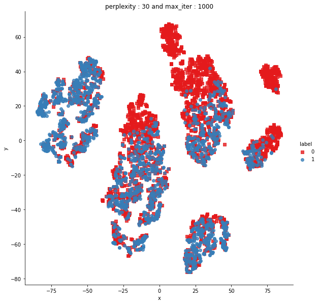

```python
df_tsne = pd.DataFrame({'x':tsne2d[:,0], 'y':tsne2d[:,1] ,'label':y})

# draw the plot in appropriate place in the grid
sns.lmplot(data=df_tsne, x='x', y='y', hue='label', fit_reg=False, size=8,palette="Set1",markers=['s','o'])
plt.title("perplexity : {} and max_iter : {}".format(30, 1000))
plt.show()
```

```python
tsne3d = TSNE(
    n_components=3,
    init='random', # pca
    random_state=101,
    method='barnes_hut',
    n_iter=1000,
    verbose=2,
    angle=0.5
).fit_transform(X)
```

```
[t-SNE] Computing 91 nearest neighbors...
[t-SNE] Indexed 5000 samples in 0.021s...
[t-SNE] Computed neighbors for 5000 samples in 0.331s...
[t-SNE] Computed conditional probabilities for sample 1000 / 5000
[t-SNE] Computed conditional probabilities for sample 2000 / 5000
[t-SNE] Computed conditional probabilities for sample 3000 / 5000
[t-SNE] Computed conditional probabilities for sample 4000 / 5000
[t-SNE] Computed conditional probabilities for sample 5000 / 5000
[t-SNE] Mean sigma: 0.131928
[t-SNE] Computed conditional probabilities in 0.176s
[t-SNE] Iteration 50: error = 80.5688934, gradient norm = 0.0322042 (50 iterations in 2.696s)
[t-SNE] Iteration 100: error = 69.4820480, gradient norm = 0.0033567 (50 iterations in 2.195s)
[t-SNE] Iteration 150: error = 68.1103058, gradient norm = 0.0017152 (50 iterations in 1.952s)
[t-SNE] Iteration 200: error = 67.5371323, gradient norm = 0.0012641 (50 iterations in 1.909s)
[t-SNE] Iteration 250: error = 67.2233887, gradient norm = 0.0009038 (50 iterations in 1.878s)
[t-SNE] KL divergence after 250 iterations with early exaggeration: 67.223389
[t-SNE] Iteration 300: error = 1.5281930, gradient norm = 0.0007159 (50 iterations in 2.139s)
[t-SNE] Iteration 350: error = 1.1899209, gradient norm = 0.0002038 (50 iterations in 2.639s)
[t-SNE] Iteration 400: error = 1.0460870, gradient norm = 0.0000988 (50 iterations in 2.527s)
[t-SNE] Iteration 450: error = 0.9748073, gradient norm = 0.0000693 (50 iterations in 2.320s)
[t-SNE] Iteration 500: error = 0.9382437, gradient norm = 0.0000566 (50 iterations in 2.154s)
[t-SNE] Iteration 550: error = 0.9175403, gradient norm = 0.0000567 (50 iterations in 2.303s)
[t-SNE] Iteration 600: error = 0.9057485, gradient norm = 0.0000469 (50 iterations in 2.271s)
[t-SNE] Iteration 650: error = 0.8995542, gradient norm = 0.0000407 (50 iterations in 2.264s)
[t-SNE] Iteration 700: error = 0.8937856, gradient norm = 0.0000322 (50 iterations in 2.261s)
[t-SNE] Iteration 750: error = 0.8864817, gradient norm = 0.0000309 (50 iterations in 2.253s)
[t-SNE] Iteration 800: error = 0.8795812, gradient norm = 0.0000333 (50 iterations in 2.210s)
[t-SNE] Iteration 850: error = 0.8746787, gradient norm = 0.0000280 (50 iterations in 2.317s)
[t-SNE] Iteration 900: error = 0.8709019, gradient norm = 0.0000267 (50 iterations in 2.211s)
[t-SNE] Iteration 950: error = 0.8667797, gradient norm = 0.0000249 (50 iterations in 2.323s)
[t-SNE] Iteration 1000: error = 0.8632098, gradient norm = 0.0000236 (50 iterations in 2.370s)
[t-SNE] KL divergence after 1000 iterations: 0.863210
```

#### 5.2 3D Scatter Plot

```python
trace1 = go.Scatter3d(
    x=tsne3d[:,0],
    y=tsne3d[:,1],
    z=tsne3d[:,2],
    mode='markers',
    marker=dict(
        sizemode='diameter',
        color = y,
        colorscale = 'Portland',
        colorbar = dict(title = 'duplicate'),
        line=dict(color='rgb(255, 255, 255)'),
        opacity=0.75
    )
)

data=[trace1]
layout=dict(height=800, width=800, title='3d embedding with engineered features')
fig=dict(data=data, layout=layout)
py.iplot(fig, filename='3DBubble')
```

[interactive chart not shown]

```python
df.head(2)
```

|  | id | qid1 | qid2 | question1 | question2 | is_duplicate | cwc_min | cwc_max | csc_min | csc_max | ... | fuzz_ratio | fuzz_partial_ratio | longest_substr_ratio | q1len | q2len | q1_n_words | q2_n_words | word_Common | word_Total | word_share |
| --- | --- | --- | --- | --- | --- | --- | --- | --- | --- | --- | --- | --- | --- | --- | --- | --- | --- | --- | --- | --- | --- |
| 0 | 0 | 1 | 2 | what is the step by step guide to invest in sh... | what is the step by step guide to invest in sh... | 0 | 0.999980 | 0.833319 | 0.999983 | 0.999983 | ... | 93 | 100 | 0.982759 | 66 | 57 | 15 | 13 | 12.0 | 25.0 | 0.480000 |
| 1 | 1 | 3 | 4 | what is the story of kohinoor koh i noor dia... | what would happen if the indian government sto... | 0 | 0.799984 | 0.399996 | 0.749981 | 0.599988 | ... | 66 | 75 | 0.596154 | 51 | 88 | 13 | 18 | 8.0 | 26.0 | 0.307692 |

2 rows × 28 columns

# 6. Featurizing text data with tfidf weighted word-vectors

```python
df['question1'] = df['question1'].apply(lambda x: str(x))
df['question2'] = df['question2'].apply(lambda x: str(x))
```

```python
# merge texts
questions = list(df['question1']) + list(df['question2'])

tfidf = TfidfVectorizer(lowercase=False, )
tfidf.fit_transform(questions)

# dict key:word and value:tf-idf score
word2tfidf = dict(zip(tfidf.get_feature_names(), tfidf.idf_))
```

```python
# en_vectors_web_lg, which includes over 1 million unique vectors.
def get_vectors(data, question_1, question_2):
    nlp = spacy.load('en_core_web_sm')
    vecs1 = []
    vecs2 = []
    # https://github.com/noamraph/tqdm
    # tqdm is used to print the progress bar
    for qu1 in tqdm(list(question_1)):
        doc1 = nlp(qu1)
        mean_vec1 = np.zeros([len(doc1), len(doc1[0].vector)])
        for word1 in doc1:
            # word2vec
            vec1 = word1.vector
            # fetch df score
            try:
                idf = word2tfidf[str(word1)]
            except:
                idf = 0
            # compute final vec
            mean_vec1 += vec1 * idf
        mean_vec1 = mean_vec1.mean(axis=0)
        vecs1.append(mean_vec1)

    for qu2 in tqdm(list(question_2)):
        doc2 = nlp(qu2)
        mean_vec2 = np.zeros([len(doc2), len(doc2[0].vector)])
        for word2 in doc2:
            # word2vec
            vec2 = word2.vector
            # fetch df score
            try:
                idf = word2tfidf[str(word2)]
            except:
                #print word
                idf = 0
            # compute final vec
            mean_vec2 += vec2 * idf
        mean_vec2 = mean_vec2.mean(axis=0)
        vecs2.append(mean_vec2)
    df_q1 = pd.DataFrame(vecs1, index= data.index)
    df_q2 = pd.DataFrame(vecs2, index= data.index)
    df_q1.columns=[str(x)+'_x' for x in df_q1.columns]
    df_q2.columns=[str(y)+'_y' for y in df_q2.columns]
    return df_q1,df_q2
```

```python
if not os.path.isfile('final_features.csv'):
    df_q1,df_q2=get_vectors(data=df, question_1=df['question1'], question_2=df['question2'])
    df_q1['id']=df['id']
    df_q2['id']=df['id']
    df = df.merge(df_q1, on='id',how='inner')
    df = df.merge(df_q2, on='id',how='inner')
    df.to_csv('final_features.csv')
    print(f'The total number of rows are {df.shape[0]} and features are {df.shape[1]}.')
```

# 7. Machine Learning Models

## 7.1 Reading data from file and storing into sql table

```python
#Creating db file from csv
if not os.path.isfile('train.db'):
    disk_engine = create_engine('sqlite:///train.db')
    start = dt.datetime.now()
    chunksize = 18000
    j = 0
    index_start = 1
    for df in pd.read_csv('final_features.csv',chunksize=chunksize, iterator=True, encoding='utf-8'):
        df.index += index_start
        j+=1
        print('{} rows'.format(j*chunksize))
        df.to_sql('data', disk_engine, if_exists='append')
        index_start = df.index[-1] + 1
```

```python
#http://www.sqlitetutorial.net/sqlite-python/create-tables/
def create_connection(db_file):
    """ create a database connection to the SQLite database
        specified by db_file
    :param db_file: database file
    :return: Connection object or None
    """
    try:
        conn = sqlite3.connect(db_file)
        return conn
    except Error as e:
        print(e)

    return None


def checkTableExists(dbcon):
    cursr = dbcon.cursor()
    str = "select name from sqlite_master where type='table'"
    table_names = cursr.execute(str)
    print("Tables in the databse:")
    tables =table_names.fetchall()
    print(tables[0][0])
    return(len(tables))
```

```python
read_db = 'train.db'
conn_r = create_connection(read_db)
checkTableExists(conn_r)
conn_r.close()
```

```
Tables in the databse:
data
```

```python
# try to sample data according to the computing power you have
if os.path.isfile(read_db):
    conn_r = create_connection(read_db)
    if conn_r is not None:
        # for selecting first 10K rows
        # data = pd.read_sql_query("""SELECT * FROM data LIMIT 100001;""", conn_r)
        # for selecting random points
        data = pd.read_sql_query("SELECT * From data ORDER BY RANDOM() LIMIT 100001;", conn_r)
        conn_r.commit()
        conn_r.close()
```

```python
# remove the first row
data.drop(data.index[0], inplace=True)
X=data.drop(['Unnamed: 0', 'id','index','is_duplicate','qid1','qid2','question1','question2'], axis=1).fillna(0)
y = list(map(int, data['is_duplicate'].values))
```

```python
X.head(2)
```

|  | cwc_min | cwc_max | csc_min | csc_max | ctc_min | ctc_max | last_word_eq | first_word_eq | abs_len_diff | mean_len | ... | 86_y | 87_y | 88_y | 89_y | 90_y | 91_y | 92_y | 93_y | 94_y | 95_y |
| --- | --- | --- | --- | --- | --- | --- | --- | --- | --- | --- | --- | --- | --- | --- | --- | --- | --- | --- | --- | --- | --- |
| 1 | 0.374995 | 0.230767 | 0.833326 | 0.624996 | 0.499998 | 0.448274 | 0.0 | 0.0 | 3.0 | 27.5 | ... | 52.123284 | 72.610425 | -33.882022 | 137.222733 | -53.870936 | -165.307769 | 155.560871 | -38.172422 | 37.408370 | -230.557812 |
| 2 | 0.599988 | 0.428565 | 0.399992 | 0.333328 | 0.499995 | 0.357140 | 1.0 | 0.0 | 4.0 | 12.0 | ... | 60.315621 | 39.286510 | -25.460524 | 63.105145 | 25.734882 | -25.544693 | -61.214853 | 1.461077 | 102.609746 | -30.504065 |

2 rows × 214 columns

## 7.2 Converting strings to numerics and Scaling the Data

```python
column_names=X.columns
for i in list(X.columns):
    X[i] = X[i].astype(float)
print("Done Coverting to Numeric........")
```

```
Done Coverting to Numeric........
```

```python
X.head(2)
```

|  | cwc_min | cwc_max | csc_min | csc_max | ctc_min | ctc_max | last_word_eq | first_word_eq | abs_len_diff | mean_len | ... | 86_y | 87_y | 88_y | 89_y | 90_y | 91_y | 92_y | 93_y | 94_y | 95_y |
| --- | --- | --- | --- | --- | --- | --- | --- | --- | --- | --- | --- | --- | --- | --- | --- | --- | --- | --- | --- | --- | --- |
| 1 | 0.374995 | 0.230767 | 0.833326 | 0.624996 | 0.499998 | 0.448274 | 0.0 | 0.0 | 3.0 | 27.5 | ... | 52.123284 | 72.610425 | -33.882022 | 137.222733 | -53.870936 | -165.307769 | 155.560871 | -38.172422 | 37.408370 | -230.557812 |
| 2 | 0.599988 | 0.428565 | 0.399992 | 0.333328 | 0.499995 | 0.357140 | 1.0 | 0.0 | 4.0 | 12.0 | ... | 60.315621 | 39.286510 | -25.460524 | 63.105145 | 25.734882 | -25.544693 | -61.214853 | 1.461077 | 102.609746 | -30.504065 |

2 rows × 214 columns

## 7.3 Random train test split( 70:30)

```python
X_train,X_test, y_train, y_test = train_test_split(X, y, stratify=y, test_size=0.3)
print("Number of data points in train data :",X_train.shape)
print("Number of data points in test data :",X_test.shape)
```

```
Number of data points in train data : (70000, 214)
Number of data points in test data : (30000, 214)
```

```python
print("-"*10, "Distribution of output variable in train data", "-"*10)
train_distr = Counter(y_train)
train_len = len(y_train)
print("Class 0: ",int(train_distr[0])/train_len,"Class 1: ", int(train_distr[1])/train_len)
test_distr = Counter(y_test)
test_len = len(y_test)
```

```
---------- Distribution of output variable in train data ----------
Class 0:  0.6304428571428572 Class 1:  0.36955714285714286
```

```python
# http://glemaitre.github.io/imbalanced-learn/generated/imblearn.under_sampling.RandomUnderSampler.html
ros= RandomUnderSampler(sampling_strategy='majority', random_state=15)
X_train, y_train = ros.fit_resample(X_train, y_train)
```

```python
print("-"*10, "Distribution of output variable in train data", "-"*10)
train_distr = Counter(y_train)
train_len = len(y_train)
print("Class 0: ",int(train_distr[0])/train_len,"Class 1: ", int(train_distr[1])/train_len)
test_distr = Counter(y_test)
test_len = len(y_test)
```

```
---------- Distribution of output variable in train data ----------
Class 0:  0.5 Class 1:  0.5
```

## 7.4 Creating Confusion Matrix Function

```python
def plot_confusion_matrix(test_y, predict_y):
    C = confusion_matrix(test_y, predict_y)
    # C = 9,9 matrix, each cell (i,j) represents number of points of class i are predicted class j

    A =(((C.T)/(C.sum(axis=1))).T)
    #divid each element of the confusion matrix with the sum of elements in that column

    # C = [[1, 2],
    #     [3, 4]]
    # C.T = [[1, 3],
    #        [2, 4]]
    # C.sum(axis = 1)  axis=0 corresonds to columns and axis=1 corresponds to rows in two diamensional array
    # C.sum(axix =1) = [[3, 7]]
    # ((C.T)/(C.sum(axis=1))) = [[1/3, 3/7]
    #                           [2/3, 4/7]]

    # ((C.T)/(C.sum(axis=1))).T = [[1/3, 2/3]
    #                           [3/7, 4/7]]
    # sum of row elements = 1

    B =(C/C.sum(axis=0))
    #divid each element of the confusion matrix with the sum of elements in that row
    # C = [[1, 2],
    #     [3, 4]]
    # C.sum(axis = 0)  axis=0 corresonds to columns and axis=1 corresponds to rows in two diamensional array
    # C.sum(axix =0) = [[4, 6]]
    # (C/C.sum(axis=0)) = [[1/4, 2/6],
    #                      [3/4, 4/6]]
    plt.figure(figsize=(20,4))

    labels = [1,2]
    plt.subplot(1, 3, 1)
    sns.heatmap(C, annot=True, fmt=".3f", xticklabels=labels, yticklabels=labels)
    plt.xlabel('Predicted Class')
    plt.ylabel('Original Class')
    plt.title("Confusion matrix")

    plt.subplot(1, 3, 2)
    sns.heatmap(B, annot=True, fmt=".3f", xticklabels=labels, yticklabels=labels)
    plt.xlabel('Predicted Class')
    plt.ylabel('Original Class')
    plt.title("Precision matrix")

    plt.subplot(1, 3, 3)
    # representing B in heatmap format
    sns.heatmap(A, annot=True, fmt=".3f", xticklabels=labels, yticklabels=labels)
    plt.xlabel('Predicted Class')
    plt.ylabel('Original Class')
    plt.title("Recall matrix")

    plt.show()
```

## 7.5 Building a random model (Finding worst-case log-loss)

```
Log loss on Test Data using Random Model 0.8754206278220503
```

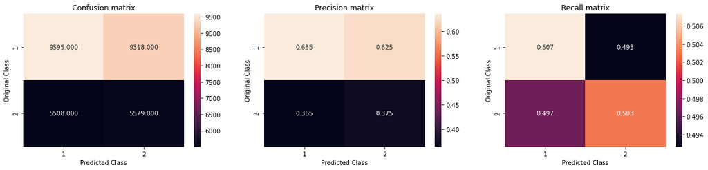

```python
# we need to generate 9 numbers and the sum of numbers should be 1
# one solution is to genarate 9 numbers and divide each of the numbers by their sum
# ref: https://stackoverflow.com/a/18662466/4084039
# we create a output array that has exactly same size as the CV data
predicted_y = np.zeros((test_len,2))
for i in range(test_len):
    rand_probs = np.random.rand(1,2)
    predicted_y[i] = ((rand_probs/sum(sum(rand_probs)))[0])
print("Log loss on Test Data using Random Model",log_loss(y_test, predicted_y, eps=1e-15))

predicted_y =np.argmax(predicted_y, axis=1)
plot_confusion_matrix(y_test, predicted_y)
```

## 7.6 Logistic Regression with hyperparameter tuning

```
For values of alpha =  1e-05 The log loss is: 0.5920976843238924
For values of alpha =  0.0001 The log loss is: 0.5832352739054836
For values of alpha =  0.001 The log loss is: 0.5838813212051374
For values of alpha =  0.01 The log loss is: 0.5672649267535702
For values of alpha =  0.1 The log loss is: 0.563150076684261
For values of alpha =  1 The log loss is: 0.5700991068533436
For values of alpha =  10 The log loss is: 0.5781586601387333
```

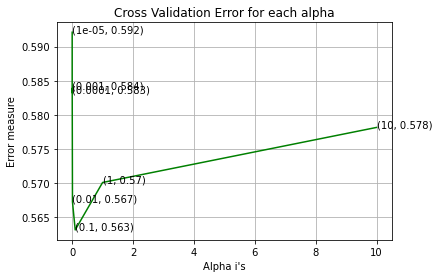

```
For values of best alpha =  0.1 The train log loss is: 0.5539021170249073
For values of best alpha =  0.1 The test log loss is: 0.563150076684261
Total number of data points : 30000
```

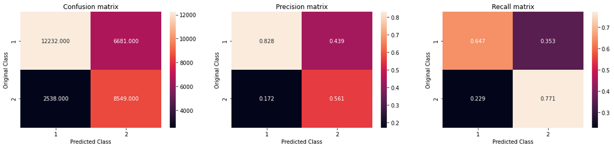

```python
alpha = [10 ** x for x in range(-5, 2)] # hyperparam for SGD classifier.

# read more about SGDClassifier() at http://scikit-learn.org/stable/modules/generated/sklearn.linear_model.SGDClassifier.html
# ------------------------------
# default parameters
# SGDClassifier(loss=’hinge’, penalty=’l2’, alpha=0.0001, l1_ratio=0.15, fit_intercept=True, max_iter=None, tol=None,
# shuffle=True, verbose=0, epsilon=0.1, n_jobs=1, random_state=None, learning_rate=’optimal’, eta0=0.0, power_t=0.5,
# class_weight=None, warm_start=False, average=False, n_iter=None)

# some of methods
# fit(X, y[, coef_init, intercept_init, …])	Fit linear model with Stochastic Gradient Descent.
# predict(X)	Predict class labels for samples in X.

#-------------------------------
# video link:
#------------------------------


log_error_array=[]
for i in alpha:
    clf = SGDClassifier(alpha=i, penalty='l2', loss='log', random_state=42)
    clf.fit(X_train, y_train)
    sig_clf = CalibratedClassifierCV(clf, method="sigmoid")
    sig_clf.fit(X_train, y_train)
    predict_y = sig_clf.predict_proba(X_test)
    log_error_array.append(log_loss(y_test, predict_y, labels=clf.classes_, eps=1e-15))
    print('For values of alpha = ', i, "The log loss is:",log_loss(y_test, predict_y, labels=clf.classes_, eps=1e-15))

fig, ax = plt.subplots()
ax.plot(alpha, log_error_array,c='g')
for i, txt in enumerate(np.round(log_error_array,3)):
    ax.annotate((alpha[i],np.round(txt,3)), (alpha[i],log_error_array[i]))
plt.grid()
plt.title("Cross Validation Error for each alpha")
plt.xlabel("Alpha i's")
plt.ylabel("Error measure")
plt.show()


best_alpha = np.argmin(log_error_array)
clf = SGDClassifier(alpha=alpha[best_alpha], penalty='l2', loss='log', random_state=42)
clf.fit(X_train, y_train)
sig_clf = CalibratedClassifierCV(clf, method="sigmoid")
sig_clf.fit(X_train, y_train)

predict_y = sig_clf.predict_proba(X_train)
print('For values of best alpha = ', alpha[best_alpha], "The train log loss is:",log_loss(y_train, predict_y, labels=clf.classes_, eps=1e-15))
predict_y = sig_clf.predict_proba(X_test)
print('For values of best alpha = ', alpha[best_alpha], "The test log loss is:",log_loss(y_test, predict_y, labels=clf.classes_, eps=1e-15))
predicted_y =np.argmax(predict_y,axis=1)
print("Total number of data points :", len(predicted_y))
plot_confusion_matrix(y_test, predicted_y)
```

## 7.7 Linear SVM with hyperparameter tuning

```
For values of alpha =  1e-05 The log loss is: 0.5562764712361931
For values of alpha =  0.0001 The log loss is: 0.5604293762987832
For values of alpha =  0.001 The log loss is: 0.5670226206998121
For values of alpha =  0.01 The log loss is: 0.5736529761984789
For values of alpha =  0.1 The log loss is: 0.6202581124516715
For values of alpha =  1 The log loss is: 0.6761975721523026
For values of alpha =  10 The log loss is: 0.6931471805599453
```

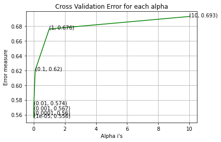

```
For values of best alpha =  1e-05 The train log loss is: 0.5487204070440199
For values of best alpha =  1e-05 The test log loss is: 0.5562764712361931
Total number of data points : 30000
```

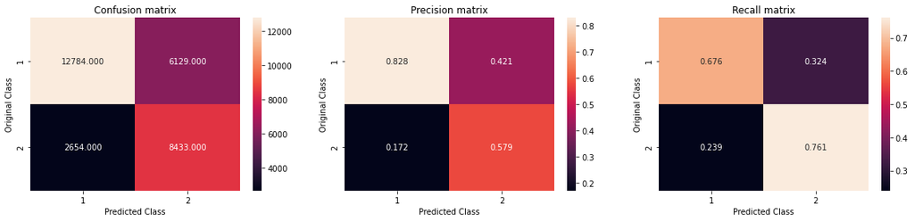

```python
alpha = [10 ** x for x in range(-5, 2)] # hyperparam for SGD classifier.

# read more about SGDClassifier() at http://scikit-learn.org/stable/modules/generated/sklearn.linear_model.SGDClassifier.html
# ------------------------------
# default parameters
# SGDClassifier(loss=’hinge’, penalty=’l2’, alpha=0.0001, l1_ratio=0.15, fit_intercept=True, max_iter=None, tol=None,
# shuffle=True, verbose=0, epsilon=0.1, n_jobs=1, random_state=None, learning_rate=’optimal’, eta0=0.0, power_t=0.5,
# class_weight=None, warm_start=False, average=False, n_iter=None)

# some of methods
# fit(X, y[, coef_init, intercept_init, …])	Fit linear model with Stochastic Gradient Descent.
# predict(X)	Predict class labels for samples in X.

#-------------------------------
# video link:
#------------------------------


log_error_array=[]
for i in alpha:
    clf = SGDClassifier(alpha=i, penalty='l1', loss='hinge', random_state=42)
    clf.fit(X_train, y_train)
    sig_clf = CalibratedClassifierCV(clf, method="sigmoid")
    sig_clf.fit(X_train, y_train)
    predict_y = sig_clf.predict_proba(X_test)
    log_error_array.append(log_loss(y_test, predict_y, labels=clf.classes_, eps=1e-15))
    print('For values of alpha = ', i, "The log loss is:",log_loss(y_test, predict_y, labels=clf.classes_, eps=1e-15))

fig, ax = plt.subplots()
ax.plot(alpha, log_error_array,c='g')
for i, txt in enumerate(np.round(log_error_array,3)):
    ax.annotate((alpha[i],np.round(txt,3)), (alpha[i],log_error_array[i]))
plt.grid()
plt.title("Cross Validation Error for each alpha")
plt.xlabel("Alpha i's")
plt.ylabel("Error measure")
plt.show()


best_alpha = np.argmin(log_error_array)
clf = SGDClassifier(alpha=alpha[best_alpha], penalty='l1', loss='hinge', random_state=42)
clf.fit(X_train, y_train)
sig_clf = CalibratedClassifierCV(clf, method="sigmoid")
sig_clf.fit(X_train, y_train)

predict_y = sig_clf.predict_proba(X_train)
print('For values of best alpha = ', alpha[best_alpha], "The train log loss is:",log_loss(y_train, predict_y, labels=clf.classes_, eps=1e-15))
predict_y = sig_clf.predict_proba(X_test)
print('For values of best alpha = ', alpha[best_alpha], "The test log loss is:",log_loss(y_test, predict_y, labels=clf.classes_, eps=1e-15))
predicted_y =np.argmax(predict_y,axis=1)
print("Total number of data points :", len(predicted_y))
plot_confusion_matrix(y_test, predicted_y)
```

## 7.8 XGBoost with Hyperparameter tuning

```python
alpha = [10 ** x for x in range(-5, 2)]
x_cfl=XGBClassifier(n_jobs=-1,verbosity=0)

param_grid = {
        'silent': [False],
        'max_depth': [3,5,10],
        'learning_rate': [0.0001,0.001,0.01,0.1],
        'subsample': [0.5, 0.6, 0.7, 0.8, 0.9, 1.0],
        'colsample_bytree': [0.4, 0.5, 0.6, 0.7, 0.8, 0.9, 1.0],
        'colsample_bylevel': [0.4, 0.5, 0.6, 0.7, 0.8, 0.9, 1.0],
        'min_child_weight': [0.5, 1.0, 3.0, 5.0, 7.0, 10.0],
        'gamma': [0, 0.25, 0.5, 1.0],
        'early_stopping_rounds':[10,20,30,50],
        'reg_lambda': alpha,
        'n_estimators': [10,100,200,500,1000,2000]}

random_cfl=RandomizedSearchCV(x_cfl,param_distributions=param_grid,n_jobs=-1,cv=3)
random_cfl.fit(X_train,y_train)
```

```
RandomizedSearchCV(cv=3,
                   estimator=XGBClassifier(base_score=None, booster=None,
                                           colsample_bylevel=None,
                                           colsample_bynode=None,
                                           colsample_bytree=None, gamma=None,
                                           gpu_id=None, importance_type='gain',
                                           interaction_constraints=None,
                                           learning_rate=None,
                                           max_delta_step=None, max_depth=None,
                                           min_child_weight=None, missing=nan,
                                           monotone_constraints=None,
                                           n_estimators=100,...
                                        'colsample_bytree': [0.4, 0.5, 0.6, 0.7,
                                                             0.8, 0.9, 1.0],
                                        'early_stopping_rounds': [10, 20, 30,
                                                                  50],
                                        'gamma': [0, 0.25, 0.5, 1.0],
                                        'learning_rate': [0.0001, 0.001, 0.01,
                                                          0.1],
                                        'max_depth': [3, 5, 10],
                                        'min_child_weight': [0.5, 1.0, 3.0, 5.0,
                                                             7.0, 10.0],
                                        'n_estimators': [10, 100, 200, 500,
                                                         1000, 2000],
                                        'reg_lambda': [1e-05, 0.0001, 0.001,
                                                       0.01, 0.1, 1, 10],
                                        'silent': [False],
                                        'subsample': [0.5, 0.6, 0.7, 0.8, 0.9,
                                                      1.0]})
```

```python
print (random_cfl.best_params_)
```

```
{'subsample': 0.9, 'silent': False, 'reg_lambda': 10, 'n_estimators': 1000, 'min_child_weight': 7.0, 'max_depth': 5, 'learning_rate': 0.1, 'gamma': 0.25, 'early_stopping_rounds': 30, 'colsample_bytree': 0.7, 'colsample_bylevel': 0.6}
```

## 7.9 XGBoost with best parameters

```
train loss 0.20626617162732805
test loss 0.4307909924011156
```

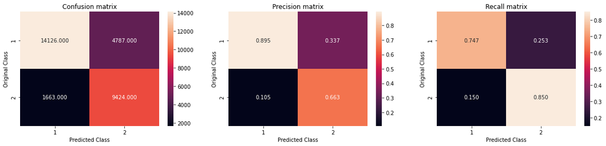

```python
x_cfl=XGBClassifier(early_stopping_rounds=random_cfl.best_params_['early_stopping_rounds'],reg_lambda=random_cfl.best_params_['reg_lambda'],gamma=random_cfl.best_params_['gamma'],min_child_weight=random_cfl.best_params_['min_child_weight'],colsample_bylevel=random_cfl.best_params_['colsample_bylevel'],colsample_bytree=random_cfl.best_params_['colsample_bytree'],subsample=random_cfl.best_params_['subsample'],n_estimators=random_cfl.best_params_['n_estimators'],learning_rate=random_cfl.best_params_['learning_rate'], max_depth=random_cfl.best_params_['max_depth'],verbosity=0)
x_cfl.fit(X_train,y_train)
c_cfl=CalibratedClassifierCV(x_cfl,method='sigmoid')
c_cfl.fit(X_train,y_train)
predict_y = c_cfl.predict_proba(X_train)
print ('train loss',log_loss(y_train, predict_y))
predict_y = c_cfl.predict_proba(X_test)
print ('test loss',log_loss(y_test, predict_y))
plot_confusion_matrix(y_test, c_cfl.predict(X_test))
```

# 8. Dumping the best model

```python
# Save to file in the current working directory
pkl_filename = "quora_similarity.pkl"
with open(pkl_filename, 'wb') as file:
    pickle.dump(c_cfl, file)

# # Load from file
# with open(pkl_filename, 'rb') as file:
#     pickle_model = pickle.load(file)
```

```python
pkl_filename = "quora_similarity.pkl"
with open(pkl_filename, 'rb') as file:
    pickle_model = pickle.load(file)

nltk.download('stopwords')
# To get the results in 4 decemal points
SAFE_DIV = 0.0001
STOP_WORDS = stopwords.words("english")
def preprocess2(x):
    x = str(x).lower()
    x = x.replace(",000,000", "m").replace(",000", "k").replace("′", "'").replace("’", "'")\
                           .replace("won't", "will not").replace("cannot", "can not").replace("can't", "can not")\
                           .replace("n't", " not").replace("what's", "what is").replace("it's", "it is")\
                           .replace("'ve", " have").replace("i'm", "i am").replace("'re", " are")\
                           .replace("he's", "he is").replace("she's", "she is").replace("'s", " own")\
                           .replace("%", " percent ").replace("₹", " rupee ").replace("$", " dollar ")\
                           .replace("€", " euro ").replace("'ll", " will")
    x = re.sub(r"([0-9]+)000000", r"\1m", x)
    x = re.sub(r"([0-9]+)000", r"\1k", x)
    porter = PorterStemmer()
    pattern = re.compile('\W')
    if type(x) == type(''):
        x = re.sub(pattern, ' ', x)
    if type(x) == type(''):
        x = porter.stem(x)
        example1 = BeautifulSoup(x)
        x = example1.get_text()
    return x

def get_token_features2(q1, q2):
    token_features = [0.0]*10
    # Converting the Sentence into Tokens:
    q1_tokens = q1.split()
    q2_tokens = q2.split()
    if len(q1_tokens) == 0 or len(q2_tokens) == 0:
        return token_features
    # Get the non-stopwords in Questions
    q1_words = set([word for word in q1_tokens if word not in STOP_WORDS])
    q2_words = set([word for word in q2_tokens if word not in STOP_WORDS])
    #Get the stopwords in Questions
    q1_stops = set([word for word in q1_tokens if word in STOP_WORDS])
    q2_stops = set([word for word in q2_tokens if word in STOP_WORDS])
    # Get the common non-stopwords from Question pair
    common_word_count = len(q1_words.intersection(q2_words))
    # Get the common stopwords from Question pair
    common_stop_count = len(q1_stops.intersection(q2_stops))
    # Get the common Tokens from Question pair
    common_token_count = len(set(q1_tokens).intersection(set(q2_tokens)))
    token_features[0] = common_word_count / (min(len(q1_words), len(q2_words)) + SAFE_DIV)
    token_features[1] = common_word_count / (max(len(q1_words), len(q2_words)) + SAFE_DIV)
    token_features[2] = common_stop_count / (min(len(q1_stops), len(q2_stops)) + SAFE_DIV)
    token_features[3] = common_stop_count / (max(len(q1_stops), len(q2_stops)) + SAFE_DIV)
    token_features[4] = common_token_count / (min(len(q1_tokens), len(q2_tokens)) + SAFE_DIV)
    token_features[5] = common_token_count / (max(len(q1_tokens), len(q2_tokens)) + SAFE_DIV)
    # Last word of both question is same or not
    token_features[6] = int(q1_tokens[-1] == q2_tokens[-1])
    # First word of both question is same or not
    token_features[7] = int(q1_tokens[0] == q2_tokens[0])
    token_features[8] = abs(len(q1_tokens) - len(q2_tokens))
    #Average Token Length of both Questions
    token_features[9] = (len(q1_tokens) + len(q2_tokens))/2
    return token_features

# get the Longest Common sub string
def get_longest_substr_ratio2(a, b):
    strs = list(distance.lcsubstrings(a, b))
    if len(strs) == 0:
        return 0
    else:
        return len(strs[0]) / (min(len(a), len(b)) + 1)

def extract_features2(df):
    # preprocessing each question
    df["question1"] = df["question1"].fillna("").apply(preprocess2)
    df["question2"] = df["question2"].fillna("").apply(preprocess2)
    # Merging Features with dataset
    token_features = df.apply(lambda x: get_token_features2(x["question1"], x["question2"]), axis=1)
    df["cwc_min"]       = list(map(lambda x: x[0], token_features))
    df["cwc_max"]       = list(map(lambda x: x[1], token_features))
    df["csc_min"]       = list(map(lambda x: x[2], token_features))
    df["csc_max"]       = list(map(lambda x: x[3], token_features))
    df["ctc_min"]       = list(map(lambda x: x[4], token_features))
    df["ctc_max"]       = list(map(lambda x: x[5], token_features))
    df["last_word_eq"]  = list(map(lambda x: x[6], token_features))
    df["first_word_eq"] = list(map(lambda x: x[7], token_features))
    df["abs_len_diff"]  = list(map(lambda x: x[8], token_features))
    df["mean_len"]      = list(map(lambda x: x[9], token_features))
    #Computing Fuzzy Features and Merging with Dataset
    # do read this blog: http://chairnerd.seatgeek.com/fuzzywuzzy-fuzzy-string-matching-in-python/
    # https://stackoverflow.com/questions/31806695/when-to-use-which-fuzz-function-to-compare-2-strings
    # https://github.com/seatgeek/fuzzywuzzy
    df["token_set_ratio"]       = df.apply(lambda x: fuzz.token_set_ratio(x["question1"], x["question2"]), axis=1)
    # The token sort approach involves tokenizing the string in question, sorting the tokens alphabetically, and
    # then joining them back into a string We then compare the transformed strings with a simple ratio().
    df["token_sort_ratio"]      = df.apply(lambda x: fuzz.token_sort_ratio(x["question1"], x["question2"]), axis=1)
    df["fuzz_ratio"]            = df.apply(lambda x: fuzz.QRatio(x["question1"], x["question2"]), axis=1)
    df["fuzz_partial_ratio"]    = df.apply(lambda x: fuzz.partial_ratio(x["question1"], x["question2"]), axis=1)
    df["longest_substr_ratio"]  = df.apply(lambda x: get_longest_substr_ratio2(x["question1"], x["question2"]), axis=1)
    return df

def normalized_word_Common2(row):
    w1 = set(map(lambda word: word.lower().strip(), row['question1'].split(" ")))
    w2 = set(map(lambda word: word.lower().strip(), row['question2'].split(" ")))
    return 1.0 * len(w1 & w2)

def normalized_word_Total2(row):
    w1 = set(map(lambda word: word.lower().strip(), row['question1'].split(" ")))
    w2 = set(map(lambda word: word.lower().strip(), row['question2'].split(" ")))
    return 1.0 * (len(w1) + len(w2))

def normalized_word_share2(row):
    w1 = set(map(lambda word: word.lower().strip(), row['question1'].split(" ")))
    w2 = set(map(lambda word: word.lower().strip(), row['question2'].split(" ")))
    return 1.0 * len(w1 & w2)/(len(w1) + len(w2))

# en_vectors_web_lg, which includes over 1 million unique vectors.
def get_vectors2(data, question_1, question_2):
    nlp = spacy.load('en_core_web_sm')
    vecs1 = []
    vecs2 = []
    # https://github.com/noamraph/tqdm
    # tqdm is used to print the progress bar
    for qu1 in tqdm(list(question_1)):
        doc1 = nlp(qu1)
        mean_vec1 = np.zeros([len(doc1), len(doc1[0].vector)])
        for word1 in doc1:
            # word2vec
            vec1 = word1.vector
            # fetch df score
            try:
                idf = word2tfidf[str(word1)]
            except:
                idf = 0
            # compute final vec
            mean_vec1 += vec1 * idf
        mean_vec1 = mean_vec1.mean(axis=0)
        vecs1.append(mean_vec1)

    for qu2 in tqdm(list(question_2)):
        doc2 = nlp(qu2)
        mean_vec2 = np.zeros([len(doc2), len(doc2[0].vector)])
        for word2 in doc2:
            # word2vec
            vec2 = word2.vector
            # fetch df score
            try:
                idf = word2tfidf[str(word2)]
            except:
                #print word
                idf = 0
            # compute final vec
            mean_vec2 += vec2 * idf
        mean_vec2 = mean_vec2.mean(axis=0)
        vecs2.append(mean_vec2)
    df_q1 = pd.DataFrame(vecs1, index= data.index)
    df_q2 = pd.DataFrame(vecs2, index= data.index)
    df_q1.columns=[str(x)+'_x' for x in df_q1.columns]
    df_q2.columns=[str(y)+'_y' for y in df_q2.columns]
    return df_q1,df_q2

def compute_similarity2(q1,q2):
    questions={'question1':[q1],'question2':[q2]}
    df=pd.DataFrame(questions)
    df['id']=pd.DataFrame(list(df.index))
    df = extract_features2(df)
    df['q1len'] = df['question1'].str.len()
    df['q2len'] = df['question2'].str.len()
    df['q1_n_words'] = df['question1'].apply(lambda row: len(row.split(" ")))
    df['q2_n_words'] = df['question2'].apply(lambda row: len(row.split(" ")))
    df['word_Common'] = df.apply(normalized_word_Common2, axis=1)
    df['word_Total'] = df.apply(normalized_word_Total2, axis=1)
    df['word_share'] = df.apply(normalized_word_share2, axis=1)
    df['question1'] = df['question1'].apply(lambda x: str(x))
    df['question2'] = df['question2'].apply(lambda x: str(x))
    # merge texts
    questions = list(df['question1']) + list(df['question2'])
    tfidf = TfidfVectorizer(lowercase=False, )
    tfidf.fit_transform(questions)
    # dict key:word and value:tf-idf score
    word2tfidf = dict(zip(tfidf.get_feature_names(), tfidf.idf_))
    df_q1,df_q2=get_vectors2(data=df, question_1=df['question1'], question_2=df['question2'])
    df_q1['id']=df['id']
    df_q2['id']=df['id']
    df = df.merge(df_q1, on='id',how='inner')
    df = df.merge(df_q2, on='id',how='inner')
    X=df.drop(['id','question1','question2'], axis=1).fillna(0)
    return X
```

```python
q1 = 'How do I read and find my YouTube comments?'
q2 = 'How can I see all my Youtube comments?'
X=compute_similarity2(q1,q2)
result=pickle_model.predict(X)[0]
probability=np.max(pickle_model.predict_proba(X))
if(result==0):
    print(f"Both the questions are different with the probability of {probability*100:.2f}%.")
else:
    print(f"Both the questions are similar with the probability of {probability*100:.2f}%.")
```

```
Both the questions are similar with the probability of 64.62%.
```

```python
q1 = 'What is the step by step guide to invest in share market in india?'
q2 = 'What is the step by step guide to invest in share market?'
X=compute_similarity2(q1,q2)
result=pickle_model.predict(X)[0]
probability=np.max(pickle_model.predict_proba(X))
if(result==0):
    print(f"Both the questions are different with the probability of {probability*100:.2f}%.")
else:
    print(f"Both the questions are similar with the probability of {probability*100:.2f}%.")
```

```
Both the questions are different with the probability of 77.85%.
```